# Blazing fast binary search in parallel with data.table

2019-02-27

## Introduction

## About me: Justin M. Shea

- Almost two decades of experience in Derivatives markets
- Visiting Professor of Finance Roosevelt University
- Organizer of [The Chicago R User Group](https://www.meetup.com/Chicago-R-User-Group/)
- Committee member [R/Finance 2019](https://www.rinfinance.com/)
- Author of the **`wooldridge`** R package, the official R package for “Introductory Econometrics” by Jeffrey M. Wooldridge.
- Author of the **`neverhpfilter`** R package, implementing James Hamilton’s alternative to the Hodrick-Prescott filter.
- [Google summer of code](https://summerofcode.withgoogle.com/) mentor 2019, R and Finance applications?

## Why data.table

```r
library(data.table)
```

- concise syntax: fast to type, fast to read
- fast speed
- memory efficient
- careful API lifecycle management
- community
- feature rich

https://github.com/Rdatatable/data.table

## Benchmarks

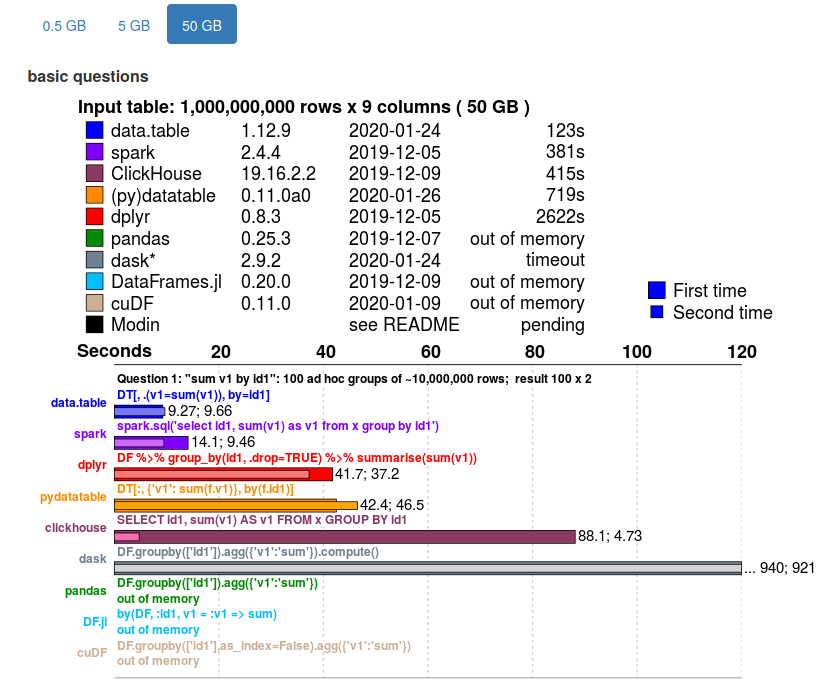

## Why I need data.table

**Problem**: Model every single equity traded in the United States since 1926.

- 34000+ securities
- Daily observations from 1926-to-present
- Survivorship Bias free

## Import Data

```r
## Import Data Actual
library(data.table)

CRSP_2659 <- fread("/media/jshea/data/CRSPdailyValue-1926-1959.csv")
CRSP_6080 <- fread("/media/jshea/data/CRSPdailyValue-1960-1979.csv")
CRSP_8000 <- fread("/media/jshea/data/CRSPdailyValue-1980-1999.csv")
CRSP_0019 <- fread("/media/jshea/data/CRSPdailyValue-2000-2019.csv")

CRSP <- rbind(CRSP_2659, CRSP_6080, CRSP_8000, CRSP_0019)
rm(CRSP_2659, CRSP_6080, CRSP_8000, CRSP_0019)

## Format Data types

CRSP$date <- as.Date(CRSP$date, "%Y/%m/%d")
CRSP$RET <- as.numeric(CRSP$RET)

# Remove missing values
sum(is.na(CRSP))
CRSP <- na.omit(CRSP)
```

## A 1 year sample: 100 seconds!

```r
CRSP_Betas <- matrix(c(9999, 0, 1, 0, 1, 100, 1, 23625), nrow = 1)

 for(permno in unique(CRSP$PERMNO)) {

      factor4 <- glm(RET ~ 0 + Q1 + Q2 + Q3 + Q4 + RmQ1 + RmQ2 + RmQ3 + RmQ4,
                     data = CRSP[permno])

    betarow <- matrix(c(permno, alpha, beta, summary(factor4)$sigma,
                        summary(factor4)$adj.r.squared,
                        summary(factor4)$fstatistic), nrow = 1)

          if(dim(betarow)[2] == 8) CRSP_Betas <- rbind(CRSP_Betas, betarow)

            }

colnames(CRSP_Betas) <- c("PERMNO", "Alpha", "Beta", "sigma", "Adj.R2", "Fstat",
                          "numeratorDF", "denominatorDF")
```

## What to do???

From `setindex` documentation

1. binary search and joins are faster when they detect they can use an existing key
2. grouping by a leading subset of the key columns is faster because the groups are already gathered contiguously in RAM
3. simpler shorter syntax; e.g. DT[“id”,] finds the group “id” in the first column of DT’s key using binary search. It may be helpful to think of a key as super-charged rownames: multi-column and multi-type rownames

`setindex` doesn’t physically reorder the entire data.table in RAM. Instead, it only computes the order for the set of columns provided and stores that order vector in an additional attribute called index.

## 94 years: 121 seconds!

With one line of code and a bracket!

```r
setindex(CRSP, PERMNO)

CRSP_Betas <- matrix(c(9999, 0, 1, 0, 1, 100, 1, 23625), nrow = 1)

 for(permno in unique(CRSP$PERMNO)) {

      factor4 <- glm(RET ~ 0 + Q1 + Q2 + Q3 + Q4 + RmQ1 + RmQ2 + RmQ3 + RmQ4,
                     data = CRSP[.(permno)])

    betarow <- matrix(c(permno, alpha, beta, summary(factor4)$sigma,
                        summary(factor4)$adj.r.squared,
                        summary(factor4)$fstatistic), nrow = 1)

          if(dim(betarow)[2] == 8) CRSP_Betas <- rbind(CRSP_Betas, betarow)

            }

colnames(CRSP_Betas) <- c("PERMNO", "Alpha", "Beta", "sigma", "Adj.R2", "Fstat",
                          "numeratorDF", "denominatorDF")
```